# General Social Survey

Heather Laughlin

Year 2019

# 1 Introduction Question 1

This data is from the 2018 General Social Survey. The first blocks of R-code has selected down a subset of the data to just 15 variables. It has further removed unwanted factor levels in much of the data. Examine that code to see what it is doing. First explain what you make out of comparing how people voted in 2012 with 2016.

How are the “voted in 2016”" and “voted in 2012”" related?

$H_0:$ voting in 2016 and 2012 are unrelated  
$H_A:$ voting in 2016 and 2012 are related

## 1.1 Methods

We used the categorical variables, and a Chi-squared test to test the hypotheseis that voting in 2016 is / is not independent of voting in 2012

## 1.2 Results

### 1.2.1 Descriptive Results

We used a barchart to show the voting trends between 2012 and 2016

#### 1.2.1.1 Graphical Descriptive Results

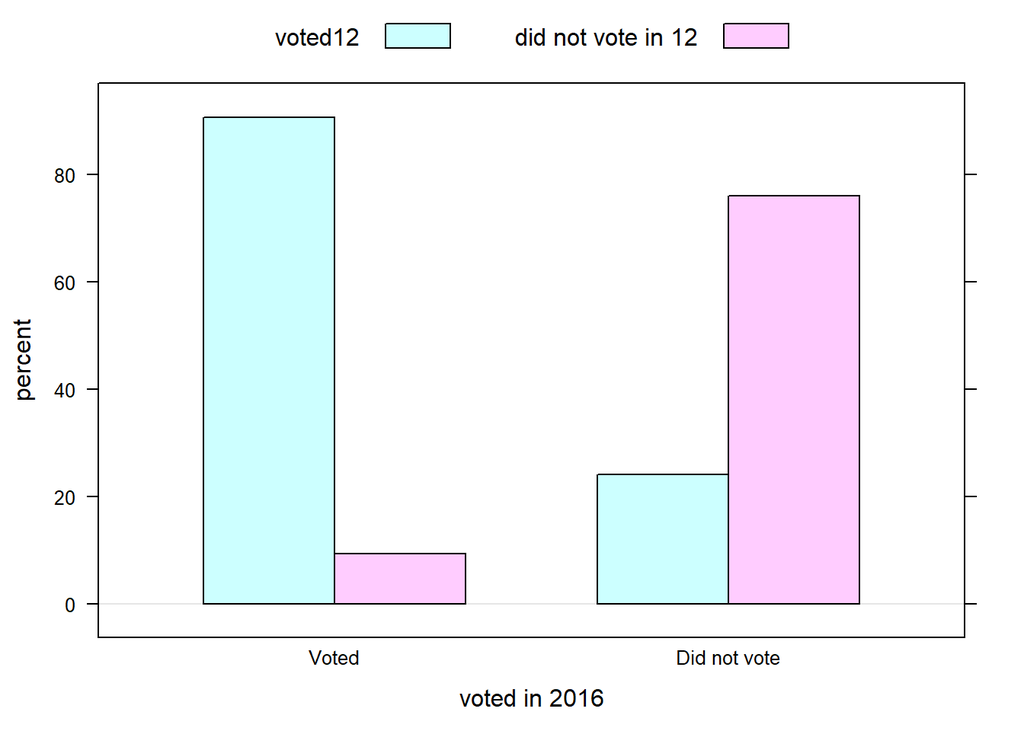

```r
barchartGC(~VOTE16+VOTE12, data=mydata4, type = "percent",xlab='voted in 2016')
```

#### 1.2.1.2 Numerical Descriptive Results

Numerical summary is a cross tabulation:

```r
xtabs(~VOTE16+VOTE12, data=mydata4)
```

```
##               VOTE12
## VOTE16         voted12 did not vote in 12
##   Voted            116                 12
##   Did not vote      12                 38
```

### 1.2.2 Inferential Results

```r
chisqtestGC(~VOTE16+VOTE12, data=mydata4)
```

```
## Pearson's Chi-squared test with Yates' continuity correction
##
## Observed Counts:
##               VOTE12
## VOTE16         voted12 did not vote in 12
##   Voted            116                 12
##   Did not vote      12                 38
##
## Counts Expected by Null:
##               VOTE12
## VOTE16         voted12 did not vote in 12
##   Voted          92.04              35.96
##   Did not vote   35.96              14.04
##
## Contributions to the chi-square statistic:
##               VOTE12
## VOTE16         voted12 did not vote in 12
##   Voted           6.23              15.96
##   Did not vote   15.96              40.86
##
##
## Chi-Square Statistic = 75.7483
## Degrees of Freedom of the table = 1
## P-Value = 0
```

```r
votetab=xtabs(~VOTE16+VOTE12, data=mydata4)
fisher.test(votetab)
```

```
##
##  Fisher's Exact Test for Count Data
##
## data:  votetab
## p-value < 2.2e-16
## alternative hypothesis: true odds ratio is not equal to 1
## 95 percent confidence interval:
##  11.74522 81.42075
## sample estimates:
## odds ratio
##   29.60721
```

$H_0:$ voting in 2016 is independent of voting in 2012  
$H_A:$ voting in 2016 is dependent of voting in 2012

The hypothesis was that voting in 2012 is related to voting in 2016. If you voted in 2012 it is likely you voted in 2016.

We did a chi-squared test to see if voting in 2016 was dependent on voting in 2012 results were 75.75.

The p-value was< 2.2e-16, so we reject the null hypothesis which is smaller than .05. Because the response and explanatory values are categorical, the bar plot and chi-squared test | test for independence.

# 2 Introduction Question 2

Now answer Is belief in the bigbang theory (BIGBANG) independent of belief in the afterlife (POSTLIFE)

We want to know if there is a correlation between belief in the “Bigbang” and belief in “Postlife”.

We got our data from the 2018 General Social Survey.

## 2.1 Methods

We used the categorical variables, and a Chi-squared test to test the hypotheseis that that belief in the “Bigbang”" is / is not independent of belief in “Postlife”.

## 2.2 Results

### 2.2.1 Descriptive Results

We used a barchart to show the data on belief in “Bigbang” and “Postlife”.

#### 2.2.1.1 Graphical Descriptive Results

[figure not shown]

```r
barchartGC(~BIGBANG+POSTLIFE, data=mydata3, type = "percent",xlab='BELIEVE IN POSTLIFE', main= 'Believe in BigBang')
```

#### 2.2.1.2 Numerical Descriptive Results

```r
xtabs(~BIGBANG+POSTLIFE, data=mydata3)
```

```
##        POSTLIFE
## BIGBANG YES  NO
##   True   86  23
##   False 109   9
```

### 2.2.2 Inferential Results

```r
chisqtestGC(~BIGBANG+POSTLIFE, data=mydata3)
```

```
## Pearson's Chi-squared test with Yates' continuity correction
##
## Observed Counts:
##        POSTLIFE
## BIGBANG YES  NO
##   True   86  23
##   False 109   9
##
## Counts Expected by Null:
##        POSTLIFE
## BIGBANG    YES    NO
##   True   93.63 15.37
##   False 101.37 16.63
##
## Contributions to the chi-square statistic:
##        POSTLIFE
## BIGBANG  YES   NO
##   True  0.62 3.79
##   False 0.57 3.50
##
##
## Chi-Square Statistic = 7.4181
## Degrees of Freedom of the table = 1
## P-Value = 0.0065
```

```r
votetab=xtabs(~BIGBANG+POSTLIFE, data=mydata3)
fisher.test(votetab)
```

```
##
##  Fisher's Exact Test for Count Data
##
## data:  votetab
## p-value = 0.004074
## alternative hypothesis: true odds ratio is not equal to 1
## 95 percent confidence interval:
##  0.1198654 0.7396911
## sample estimates:
## odds ratio
##  0.3103104
```

$H_0:$ belief in “Bigbang” is independent on belief of “Postlife” $H_A:$ belief in “Bigbang” is dependent on belief of “Postlife”

The null hypothesis was that belief in “Postlife” is unrelated to belief in “Bigbang”.

There is a correlation between not believing in “Postlife” and believing on “Bigbang”. there us a strong correlation between not believeing in “Postlife” and believing in “Bigbang”. However, there is a larger percent of people who believe in both “Bigbang” and “Postlife”. There are very few who do not believe in either “Bigbang” nor “Postlife”

If you believe in “Bigbang” it is likely you believe in “Postlife”. We did a chi-squared test to see if “Postlife” was dependent on “Bigbang”, the results was 7.4181.

The p-value was 0.004074, so we reject the null hypothesis which is smaller than .05.

Because the response and explanatory values are categorical, the bar plot and chi-squared test | test for independence.

# 3 Introduction Question 3

This time compare the opinion on death penalty (CAPPUN) with opinion on courts (COURTS).

This data is from the 2018 General Social Survey. Is there a relationship between an opinion on the death penatly (CAPPUN) and the opinion on courts (COURTS).

## 3.1 Methods

We used the categorical variables, and a Chi-squared test to test the hypotheseis that that the opinion in the “CAPPUN”" is / is not independent of opinion in “COURTS”.

## 3.2 Results

### 3.2.1 Descriptive Results

We used a barchart to show the data on opinion on courts.

#### 3.2.1.1 Graphical Descriptive Results

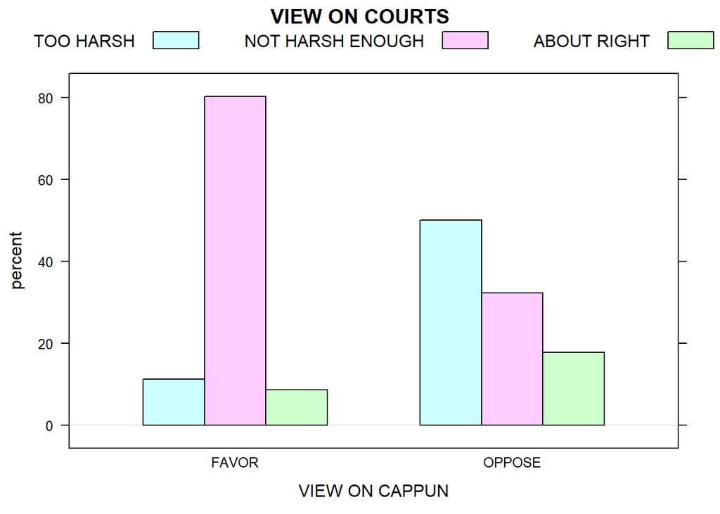

```r
barchartGC(~CAPPUN+COURTS, data=mydata5, type = "percent",xlab='VIEW ON CAPPUN', main= 'VIEW ON COURTS')
```

#### 3.2.1.2 Numerical Descriptive Results

```r
xtabs(~CAPPUN+COURTS, data=mydata5)
```

```
##         COURTS
## CAPPUN   TOO HARSH NOT HARSH ENOUGH ABOUT RIGHT
##   FAVOR         13               93          10
##   OPPOSE        31               20          11
```

### 3.2.2 Inferential Results

```r
chisqtestGC(~CAPPUN+COURTS, data=mydata5)
```

```
## Pearson's Chi-squared test
##
## Observed Counts:
##         COURTS
## CAPPUN   TOO HARSH NOT HARSH ENOUGH ABOUT RIGHT
##   FAVOR         13               93          10
##   OPPOSE        31               20          11
##
## Counts Expected by Null:
##         COURTS
## CAPPUN   TOO HARSH NOT HARSH ENOUGH ABOUT RIGHT
##   FAVOR      28.67            73.64       13.69
##   OPPOSE     15.33            39.36        7.31
##
## Contributions to the chi-square statistic:
##         COURTS
## CAPPUN   TOO HARSH NOT HARSH ENOUGH ABOUT RIGHT
##   FAVOR       8.57             5.09        0.99
##   OPPOSE     16.03             9.52        1.86
##
##
## Chi-Square Statistic = 42.0594
## Degrees of Freedom of the table = 2
## P-Value = 0
```

```r
votetab=xtabs(~CAPPUN+COURTS, data=mydata5)
fisher.test(votetab)
```

```
##
##  Fisher's Exact Test for Count Data
##
## data:  votetab
## p-value = 4.35e-10
## alternative hypothesis: two.sided
```

$H_0:$ There is no relationship between the view of the courts and the view on capital punishment. $H_A:$ There is a relationship between the view of the courts and the view on capital punishment.

The p-value was 4.35e-10, so we reject the null hypothesis which is smaller than .05

# 4 Discussion and Conclusion

All three examples seemed to have some correlation in their variables. The 2012 voters mostly voted in 2016 and non’s did not; it seemed that people tended to vote or not consistenetly. The non-belief in “POSTLIFE” seemed directly related to belief in the “BIGBANG”. Though there was a larger group who believed in both the “BIGBANG” and “POSTLIFE”. The “CAPPUN”went directly with the group who felt the “COURTS” were too lenient.